# Exercise: using Paradata

Marga Torre

2026-03-03

## Intro

Individuals’ ideology is one of the most relevant factors in vote prediction models. However, it is also one of the questions that generally has the highest rate of non-response, which poses a problem when making electoral estimates.

Using the ESS core data and the Interviewer Data File from Round 10 (2020-2022) for all countries, answer the following questions:

- Is the non-response rate higher in some countries than in others?
- What profile of interviewee is more likely to not reveal their ideology?
- In what way - if any - does the interviewer’s profile affect non-response?

## Read data

Load both the core data and the interviewer’s data file (Round 10) for all countries (ESS10.csv, ESS20_INT.csv)

```r
data <- read_csv("ESS10.csv")
paradata <- read_csv("ESS10_INT.csv")
```

Merge the two datasets by country and identification number

```r
data <- left_join(data, paradata, by = c("cntry", "idno")) |>
  rename_with(~str_replace(., "\\.y$", ""), .cols = ends_with(".y")) |>
  select(-ends_with(".x"))
```

## Diferences by country

Examine the distribution of missing values (NA) in the variable ideology by country:

```r
data <- data |>
  mutate(ideology_na = ifelse(lrscale > 10, 1, 0))
prop.table(table(data$cntry, data$ideology_na), margin=1)*100
```

```
##
##              0         1
##   AT 94.907639  5.092361
##   BE 95.302013  4.697987
##   BG 86.534216 13.465784
##   CH 93.434012  6.565988
##   CY 94.628571  5.371429
##   CZ 88.368336 11.631664
##   DE 93.249284  6.750716
##   EE 91.763943  8.236057
##   ES 94.480946  5.519054
##   FI 96.322131  3.677869
##   FR 88.720283 11.279717
##   GB 93.559617  6.440383
##   GR 88.388710 11.611290
##   HR 87.688442 12.311558
##   HU 85.992428 14.007572
##   IE 85.649718 14.350282
##   IL 96.330275  3.669725
##   IS 94.241417  5.758583
##   IT 74.204545 25.795455
##   LT 73.056058 26.943942
##   LV 92.375367  7.624633
##   ME 67.762128 32.237872
##   MK 61.581526 38.418474
##   NL 95.850340  4.149660
##   NO 97.448618  2.551382
##   PL 95.157385  4.842615
##   PT 79.216540 20.783460
##   RS 87.176080 12.823920
##   SE 97.944906  2.055094
##   SI 86.182109 13.817891
##   SK 87.940762 12.059238
```

Alternatively, you can plot the proportion of NA

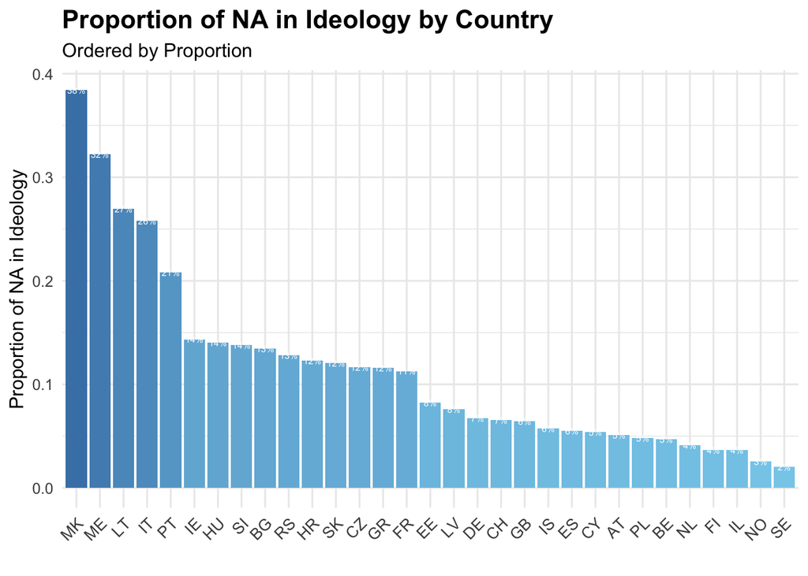

```r
# Calculate the proportion of ideology_na = 1 by country
data2 <- data |>
  group_by(cntry) |>
  summarise(proportion_na = mean(ideology_na))

ggplot(data2, aes(x = reorder(cntry, -proportion_na), y = proportion_na, fill = proportion_na)) +
  geom_bar(stat = "identity") +
  scale_fill_gradient(low = "skyblue", high = "steelblue", name = "") +
  geom_text(aes(label = percent(proportion_na, accuracy = 1)), position = position_stack(vjust = 0.5), color = "white", size = 2) +
  labs(x = "", y = "Proportion of NA in Ideology", title = "Proportion of NA in Ideology by Country", subtitle = "Ordered by Proportion") +
  theme_minimal(base_size = 12) +
  theme(axis.text.x = element_text(angle = 45, hjust = 1, size = 10),
        axis.title = element_text(size = 12),
        plot.title = element_text(size = 16, face = "bold"),
        plot.subtitle = element_text(size = 12),
        legend.position = "none") +
  guides(fill = guide_legend(reverse = TRUE))
```

As observed, the proportion of non-responses in the variable `ideology` ranges from 38% in North Macedonia to 2%-4% in the Nordic countries. Spain stands out with a 6% non-response rate, which is among the lower rates recorded. It’s notable the difference with Italy, where 1 out of 4 citizens do not report their ideology.

## The effect of individual’s profile

Prepare the variables `gender` and `age`table() of the individual for the analysis

```r
# gender (man/woman)
data <- data |>
  mutate(gender = factor(ifelse(gndr == 1, "man", ifelse(gndr == 2, "woman", NA))))
table(data$gender)
```

```
##
##   man woman
## 27765 31285
```

```r
# age
data <- data |>
  mutate(age = ifelse(agea == 999, NA, agea))
summary(data$age)
```

```
##    Min. 1st Qu.  Median    Mean 3rd Qu.    Max.    NA's
##   15.00   36.00   51.00   50.47   65.00   90.00    1338
```

```r
m0<-glm(ideology_na ~ gender + age + factor(cntry), data, family="binomial")
summary(m0)
```

```
##
## Call:
## glm(formula = ideology_na ~ gender + age + factor(cntry), family = "binomial",
##     data = data)
##
## Coefficients:
##                   Estimate Std. Error z value Pr(>|z|)
## (Intercept)     -3.0289597  0.1175442 -25.769  < 2e-16 ***
## genderwoman      0.3622314  0.0284001  12.755  < 2e-16 ***
## age             -0.0043383  0.0007599  -5.709 1.14e-08 ***
## factor(cntry)BE  0.0345931  0.1699747   0.204 0.838729
## factor(cntry)BG  1.1862418  0.1241932   9.552  < 2e-16 ***
## factor(cntry)CH  0.3804726  0.1521274   2.501 0.012384 *
## factor(cntry)CY  0.0469285  0.1931329   0.243 0.808017
## factor(cntry)CZ  0.9920453  0.1270855   7.806 5.90e-15 ***
## factor(cntry)DE  0.1885255  0.1208655   1.560 0.118808
## factor(cntry)EE  0.6279107  0.1442645   4.352 1.35e-05 ***
## factor(cntry)ES  0.1908263  0.1438284   1.327 0.184587
## factor(cntry)FI -0.2095624  0.1735926  -1.207 0.227352
## factor(cntry)FR  0.9846356  0.1314556   7.490 6.87e-14 ***
## factor(cntry)GB  0.3522195  0.1645709   2.140 0.032336 *
## factor(cntry)GR  0.9751980  0.1260020   7.740 9.98e-15 ***
## factor(cntry)HR  1.0357902  0.1355389   7.642 2.14e-14 ***
## factor(cntry)HU  1.1954264  0.1293041   9.245  < 2e-16 ***
## factor(cntry)IE  1.2640987  0.1300125   9.723  < 2e-16 ***
## factor(cntry)IL -0.7775490  0.2272143  -3.422 0.000621 ***
## factor(cntry)IS  0.2461633  0.1807048   1.362 0.173122
## factor(cntry)IT  1.9951076  0.1193220  16.720  < 2e-16 ***
## factor(cntry)LT  2.0238996  0.1236659  16.366  < 2e-16 ***
## factor(cntry)LV  0.4594706  0.1655949   2.775 0.005526 **
## factor(cntry)ME  2.3110905  0.1259343  18.352  < 2e-16 ***
## factor(cntry)MK  2.5786145  0.1234040  20.896  < 2e-16 ***
## factor(cntry)NL -0.0921499  0.1712874  -0.538 0.590588
## factor(cntry)NO -0.6047605  0.2018458  -2.996 0.002734 **
## factor(cntry)PL -0.0751980  0.1570342  -0.479 0.632035
## factor(cntry)PT  1.7051086  0.1246780  13.676  < 2e-16 ***
## factor(cntry)RS  1.0636871  0.1385641   7.676 1.63e-14 ***
## factor(cntry)SE -0.8716691  0.1881510  -4.633 3.61e-06 ***
## factor(cntry)SI  1.2075909  0.1376335   8.774  < 2e-16 ***
## factor(cntry)SK  0.9833650  0.1398440   7.032 2.04e-12 ***
## ---
## Signif. codes:  0 '***' 0.001 '**' 0.01 '*' 0.05 '.' 0.1 ' ' 1
##
## (Dispersion parameter for binomial family taken to be 1)
##
##     Null deviance: 39903  on 58184  degrees of freedom
## Residual deviance: 36015  on 58152  degrees of freedom
##   (1500 observations deleted due to missingness)
## AIC: 36081
##
## Number of Fisher Scoring iterations: 6
```

Check whether the effect of age is linear. Discuss teh results.

```r
m0b<-glm(ideology_na ~ gender + age + I(age^2) + factor(cntry), data, family=binomial(link = "logit"))
summary(m0b)
```

```
##
## Call:
## glm(formula = ideology_na ~ gender + age + I(age^2) + factor(cntry),
##     family = binomial(link = "logit"), data = data)
##
## Coefficients:
##                   Estimate Std. Error z value Pr(>|z|)
## (Intercept)     -2.183e+00  1.427e-01 -15.299  < 2e-16 ***
## genderwoman      3.602e-01  2.844e-02  12.666  < 2e-16 ***
## age             -4.344e-02  3.876e-03 -11.208  < 2e-16 ***
## I(age^2)         3.914e-04  3.804e-05  10.289  < 2e-16 ***
## factor(cntry)BE  1.156e-02  1.701e-01   0.068 0.945821
## factor(cntry)BG  1.179e+00  1.243e-01   9.490  < 2e-16 ***
## factor(cntry)CH  3.638e-01  1.522e-01   2.390 0.016856 *
## factor(cntry)CY  5.839e-02  1.932e-01   0.302 0.762526
## factor(cntry)CZ  9.925e-01  1.272e-01   7.805 5.97e-15 ***
## factor(cntry)DE  1.692e-01  1.210e-01   1.399 0.161723
## factor(cntry)EE  6.160e-01  1.444e-01   4.267 1.98e-05 ***
## factor(cntry)ES  1.847e-01  1.439e-01   1.283 0.199398
## factor(cntry)FI -2.359e-01  1.737e-01  -1.358 0.174515
## factor(cntry)FR  9.707e-01  1.316e-01   7.378 1.61e-13 ***
## factor(cntry)GB  3.347e-01  1.647e-01   2.032 0.042127 *
## factor(cntry)GR  9.892e-01  1.261e-01   7.845 4.32e-15 ***
## factor(cntry)HR  1.022e+00  1.356e-01   7.536 4.83e-14 ***
## factor(cntry)HU  1.182e+00  1.294e-01   9.136  < 2e-16 ***
## factor(cntry)IE  1.258e+00  1.301e-01   9.668  < 2e-16 ***
## factor(cntry)IL -8.044e-01  2.273e-01  -3.539 0.000402 ***
## factor(cntry)IS  2.315e-01  1.808e-01   1.281 0.200362
## factor(cntry)IT  1.985e+00  1.194e-01  16.623  < 2e-16 ***
## factor(cntry)LT  2.023e+00  1.238e-01  16.342  < 2e-16 ***
## factor(cntry)LV  4.504e-01  1.657e-01   2.718 0.006570 **
## factor(cntry)ME  2.314e+00  1.261e-01  18.356  < 2e-16 ***
## factor(cntry)MK  2.587e+00  1.235e-01  20.945  < 2e-16 ***
## factor(cntry)NL -1.043e-01  1.714e-01  -0.608 0.542892
## factor(cntry)NO -6.156e-01  2.019e-01  -3.048 0.002301 **
## factor(cntry)PL -9.357e-02  1.571e-01  -0.596 0.551498
## factor(cntry)PT  1.693e+00  1.248e-01  13.572  < 2e-16 ***
## factor(cntry)RS  1.064e+00  1.387e-01   7.670 1.73e-14 ***
## factor(cntry)SE -9.061e-01  1.883e-01  -4.813 1.48e-06 ***
## factor(cntry)SI  1.190e+00  1.378e-01   8.635  < 2e-16 ***
## factor(cntry)SK  9.963e-01  1.399e-01   7.119 1.09e-12 ***
## ---
## Signif. codes:  0 '***' 0.001 '**' 0.01 '*' 0.05 '.' 0.1 ' ' 1
##
## (Dispersion parameter for binomial family taken to be 1)
##
##     Null deviance: 39903  on 58184  degrees of freedom
## Residual deviance: 35912  on 58151  degrees of freedom
##   (1500 observations deleted due to missingness)
## AIC: 35980
##
## Number of Fisher Scoring iterations: 6
```

Incorporating non-linear terms, such as quadratic functions, enables us to capture nuanced patterns that might otherwise go unnoticed. This method enhances the precision and depth of our findings, revealing more complex relationships between age and the dependent variable.

## The effect of interviewer’s profile

Now, utilize paradata to investigate the impact of the interviewer’s profile on the likelihood of non-response. Specifically, analyze the effects of the interviewer’s gender, age, and interviewer’s overall experience conducting the survey

```r
# gender of the interviewer (man/woman)
data <- data |>
  mutate(intgender = factor(ifelse(intgndr == 1, "man", ifelse(intgndr == 2, "woman", NA))))
table(data$intgender)
```

```
##
##   man woman
## 10979 24771
```

```r
# age of the interviewer
data <- data |>
  mutate(intage = ifelse(intagea == 999, NA, intagea))
summary(data$intage)
```

```
##    Min. 1st Qu.  Median    Mean 3rd Qu.    Max.    NA's
##   18.00   43.00   53.00   51.81   62.00   82.00   23950
```

```r
# overall experience conducting the interview
data <- data |>
  mutate(intexperience = ifelse(vdovexin >10, NA, vdovexin))
summary(data$experience)
```

```
## Length  Class   Mode
##      0   NULL   NULL
```

Run the regression and discuss the results

```r
m1<-glm(ideology_na ~ gender + age  + intgender + intage +  intexperience + factor(cntry), data, family=binomial(link = "logit"))
summary(m1)
```

```
##
## Call:
## glm(formula = ideology_na ~ gender + age + intgender + intage +
##     intexperience + factor(cntry), family = binomial(link = "logit"),
##     data = data)
##
## Coefficients:
##                   Estimate Std. Error z value Pr(>|z|)
## (Intercept)     -1.7176423  0.1844882  -9.310  < 2e-16 ***
## genderwoman      0.3181994  0.0345938   9.198  < 2e-16 ***
## age             -0.0085033  0.0009432  -9.016  < 2e-16 ***
## intgenderwoman   0.4225005  0.0426926   9.896  < 2e-16 ***
## intage           0.0006371  0.0014575   0.437  0.66206
## intexperience   -0.1500157  0.0098498 -15.230  < 2e-16 ***
## factor(cntry)BG  0.8304915  0.1434206   5.791 7.01e-09 ***
## factor(cntry)CH  0.3544231  0.1666331   2.127  0.03342 *
## factor(cntry)EE  0.4294922  0.1605513   2.675  0.00747 **
## factor(cntry)FI -0.3934971  0.1873044  -2.101  0.03565 *
## factor(cntry)FR  0.9046611  0.1480238   6.112 9.86e-10 ***
## factor(cntry)GB  0.2892600  0.1783330   1.622  0.10480
## factor(cntry)GR  0.7833751  0.1457513   5.375 7.67e-08 ***
## factor(cntry)IE  1.1345353  0.1470588   7.715 1.21e-14 ***
## factor(cntry)IS  0.0946984  0.1960184   0.483  0.62902
## factor(cntry)IT  1.7558317  0.1382910  12.697  < 2e-16 ***
## factor(cntry)LT  1.7354519  0.1434718  12.096  < 2e-16 ***
## factor(cntry)ME  2.1959282  0.1463620  15.003  < 2e-16 ***
## factor(cntry)MK  2.4535079  0.1434900  17.099  < 2e-16 ***
## factor(cntry)NL -0.2124123  0.1843886  -1.152  0.24933
## factor(cntry)NO -0.6020647  0.2137248  -2.817  0.00485 **
## factor(cntry)PT  1.4841440  0.1431783  10.366  < 2e-16 ***
## factor(cntry)SI  1.1521310  0.1546158   7.452 9.22e-14 ***
## factor(cntry)SK  0.7354539  0.1570537   4.683 2.83e-06 ***
## ---
## Signif. codes:  0 '***' 0.001 '**' 0.01 '*' 0.05 '.' 0.1 ' ' 1
##
## (Dispersion parameter for binomial family taken to be 1)
##
##     Null deviance: 25586  on 31254  degrees of freedom
## Residual deviance: 22886  on 31231  degrees of freedom
##   (28430 observations deleted due to missingness)
## AIC: 22934
##
## Number of Fisher Scoring iterations: 6
```

Note the impact of allowing age to have a non-linear effect:

```r
m1b<-glm(ideology_na ~ gender + age + I(age^2) + intgender + intage + I(intage^2) + intexperience + factor(cntry), data, family=binomial(link = "logit"))
summary(m1b)
```

```
##
## Call:
## glm(formula = ideology_na ~ gender + age + I(age^2) + intgender +
##     intage + I(intage^2) + intexperience + factor(cntry), family = binomial(link = "logit"),
##     data = data)
##
## Coefficients:
##                   Estimate Std. Error z value Pr(>|z|)
## (Intercept)     -1.896e+00  2.672e-01  -7.095 1.30e-12 ***
## genderwoman      3.141e-01  3.467e-02   9.058  < 2e-16 ***
## age             -5.000e-02  4.798e-03 -10.421  < 2e-16 ***
## I(age^2)         4.125e-04  4.688e-05   8.799  < 2e-16 ***
## intgenderwoman   3.978e-01  4.301e-02   9.249  < 2e-16 ***
## intage           4.904e-02  8.356e-03   5.870 4.37e-09 ***
## I(intage^2)     -5.058e-04  8.631e-05  -5.861 4.61e-09 ***
## intexperience   -1.446e-01  9.879e-03 -14.639  < 2e-16 ***
## factor(cntry)BG  8.553e-01  1.436e-01   5.957 2.57e-09 ***
## factor(cntry)CH  3.969e-01  1.670e-01   2.377  0.01745 *
## factor(cntry)EE  4.140e-01  1.608e-01   2.575  0.01003 *
## factor(cntry)FI -4.731e-01  1.878e-01  -2.519  0.01177 *
## factor(cntry)FR  8.759e-01  1.484e-01   5.903 3.56e-09 ***
## factor(cntry)GB  2.749e-01  1.786e-01   1.539  0.12377
## factor(cntry)GR  7.505e-01  1.465e-01   5.124 2.99e-07 ***
## factor(cntry)IE  1.189e+00  1.475e-01   8.061 7.56e-16 ***
## factor(cntry)IS  6.884e-02  1.962e-01   0.351  0.72576
## factor(cntry)IT  1.721e+00  1.388e-01  12.402  < 2e-16 ***
## factor(cntry)LT  1.732e+00  1.437e-01  12.051  < 2e-16 ***
## factor(cntry)ME  2.222e+00  1.465e-01  15.168  < 2e-16 ***
## factor(cntry)MK  2.448e+00  1.439e-01  17.015  < 2e-16 ***
## factor(cntry)NL -2.103e-01  1.846e-01  -1.139  0.25461
## factor(cntry)NO -6.386e-01  2.140e-01  -2.984  0.00284 **
## factor(cntry)PT  1.453e+00  1.436e-01  10.118  < 2e-16 ***
## factor(cntry)SI  1.077e+00  1.553e-01   6.936 4.04e-12 ***
## factor(cntry)SK  7.428e-01  1.574e-01   4.719 2.37e-06 ***
## ---
## Signif. codes:  0 '***' 0.001 '**' 0.01 '*' 0.05 '.' 0.1 ' ' 1
##
## (Dispersion parameter for binomial family taken to be 1)
##
##     Null deviance: 25586  on 31254  degrees of freedom
## Residual deviance: 22779  on 31229  degrees of freedom
##   (28430 observations deleted due to missingness)
## AIC: 22831
##
## Number of Fisher Scoring iterations: 6
```

In this scenario, the interviewer’s age becomes significant and non-linear. The main and quadratic effects show there’s a peak. Simply put, the probability of not getting a response goes up with age until it hits a certain point, and then it starts to go down

Finally enhance the regression analysis by introducing a new variable that quantifies the gender match (or mismatch) between the interviewer and the interviewee.

1. mixed (m-f or f-m)
2. female-female
3. male-male

```r
data <- data |>
  filter(gndr <= 9, intgndr <= 9) |>
  mutate(gender_combination = factor(case_when(
    gndr == 1 & intgndr == 1 ~ "male-male",    # male-male
    gndr == 2 & intgndr == 2 ~ "female-female", # female-female
    gndr == 1 & intgndr == 2 ~ "mixed",   # male-female
    gndr == 2 & intgndr == 1 ~ "mixed"    # female-male
  )))

# Table of gender_combination
table(data$gender_combination)
```

```
##
## female-female     male-male         mixed
##         13464          5453         16833
```

Run the regression and discuss the results.

```r
m1c<-glm(ideology_na ~ age + I(age^2) + gender_combination + intage + I(intage^2) + intexperience + factor(cntry), data, family=binomial(link = "logit"))
summary(m1c)
```

[output not shown]

We observe that both male-male and mixed-gender pairings reduce the probability of non-response compared to female-female pairings. These results might suggest that female interviewers may benefit from additional training. To obtain more detailed information, we could separate mixed categories by the sex of the interviewer.

## Extracting tables from R statistical output

[Stargazer](https://cran.r-project.org/web/packages/stargazer/vignettes/stargazer.pdf) is an R package that creates LATEX code, HTML code and ASCII text for well-formatted regression tables. Let’s see an example to extrat models m1b and m1c

```r
library(stargazer)

stargazer(m1b, m1c,
          type="text",
          dep.var.labels=c("Probability of non-response in ideology"),
          keep = c(
            "(Intercept)",
            "age",
            "I(age^2)",
            "gender_combinationmale-male",
            "gender_combinationmixed",
            "intage",
            "I(intage^2)",
            "intexperience"),
          covariate.labels = c(
            "Age of the interviewee",
            "Age of the interviewee (squared)",
            "Pair: male-male (rc: female-famale)",
            "Pair: mixed (rc: female-famale)",
            "Age of the interviewer",
            "Age of the interviewer (squared)",
            "Overall experience of the interviewer"),
          out="models.txt")
```

```
##
## ==============================================================================
##                                                 Dependent variable:
##                                       ----------------------------------------
##                                       Probability of non-response in ideology
##                                               (1)                  (2)
## ------------------------------------------------------------------------------
## Age of the interviewee                     -0.050***            -0.050***
##                                             (0.005)              (0.005)
##
## Age of the interviewee (squared)           0.0004***            0.0004***
##                                            (0.00005)            (0.00005)
##
## Pair: male-male (rc: female-famale)                             -0.723***
##                                                                  (0.061)
##
## Pair: mixed (rc: female-famale)                                 -0.322***
##                                                                  (0.037)
##
## Age of the interviewer                      0.049***            0.050***
##                                             (0.008)              (0.008)
##
## Age of the interviewer (squared)           -0.001***            -0.001***
##                                             (0.0001)            (0.0001)
##
## Overall experience of the interviewer      -0.145***            -0.144***
##                                             (0.010)              (0.010)
##
## ------------------------------------------------------------------------------
## Observations                                 31,255              31,255
## Log Likelihood                            -11,389.480          -11,390.110
## Akaike Inf. Crit.                          22,830.970          22,832.220
## ==============================================================================
## Note:                                              *p<0.1; **p<0.05; ***p<0.01
```